# Gene Set Enrichment Analysis with ClusterProfiler

Mohammed Khalfan

5/19/2019

This R Notebook describes the implementation of gene set enrichment analysis (GSEA) using the clusterProfiler package. For more information please see the full documentation here: https://bioconductor.org/packages/release/bioc/vignettes/clusterProfiler/inst/doc/clusterProfiler.html

# Install and load required packages

```r
#BiocManager::install("clusterProfiler", version = "3.8")
#BiocManager::install("pathview")
#BiocManager::install("enrichplot")
library(clusterProfiler)
library(enrichplot)
# we use ggplot2 to add x axis labels (ex: ridgeplot)
library(ggplot2)
```

# Annotations

I’m using *D melanogaster* data, so I install and load the annotation “org.Dm.eg.db” below. See all annotations available here: http://bioconductor.org/packages/release/BiocViews.html#___OrgDb (there are 19 presently available).

```r
# SET THE DESIRED ORGANISM HERE
organism = "org.Dm.eg.db"
#BiocManager::install(organism, character.only = TRUE)
library(organism, character.only = TRUE)
```

# Prepare Input

```r
# reading in data from deseq2
df = read.csv("drosphila_example_de.csv", header=TRUE)

# we want the log2 fold change
original_gene_list <- df$log2FoldChange

# name the vector
names(original_gene_list) <- df$X

# omit any NA values
gene_list<-na.omit(original_gene_list)

# sort the list in decreasing order (required for clusterProfiler)
gene_list = sort(gene_list, decreasing = TRUE)
```

## Gene Set Enrichment

Params:

**keyType** This is the source of the annotation (gene ids). The options vary for each annotation. In the example of *org.Dm.eg.db*, the options are:

“ACCNUM” “ALIAS” “ENSEMBL” “ENSEMBLPROT” “ENSEMBLTRANS” “ENTREZID”  
“ENZYME” “EVIDENCE” “EVIDENCEALL” “FLYBASE” “FLYBASECG” “FLYBASEPROT”  
“GENENAME” “GO” “GOALL” “MAP” “ONTOLOGY” “ONTOLOGYALL”  
“PATH” “PMID” “REFSEQ” “SYMBOL” “UNIGENE” “UNIPROT”

Check which options are available with the `keytypes` command, for example `keytypes(org.Dm.eg.db)`.

**ont** one of “BP”, “MF”, “CC” or “ALL”  
**nPerm** permutation numbers, the higher the number of permutations you set, the more accurate your results is, but it will also cost longer time for running permutation.  
**minGSSize** minimal size of each geneSet for analyzing.  
**maxGSSize** maximal size of genes annotated for testing.  
**pvalueCutoff** pvalue Cutoff.  
**pAdjustMethod** one of “holm”, “hochberg”, “hommel”, “bonferroni”, “BH”, “BY”, “fdr”, “none”

```r
gse <- gseGO(geneList=gene_list,
             ont ="ALL",
             keyType = "ENSEMBL",
             nPerm = 10000,
             minGSSize = 3,
             maxGSSize = 800,
             pvalueCutoff = 0.05,
             verbose = TRUE,
             OrgDb = organism,
             pAdjustMethod = "none")
```

```
## preparing geneSet collections...
```

```
## GSEA analysis...
```

```
## leading edge analysis...
```

```
## done...
```

# Output

## Table of results

```r
head(gse)
```

|  | ONTOLOGY | ID | Description | setSize | enrichmentScore | NES | pvalue | p.adjust | qvalues | rank | leading_edge | core_enrichment |
| --- | --- | --- | --- | --- | --- | --- | --- | --- | --- | --- | --- | --- |
| GO:0044459 | CC | GO:0044459 | plasma membrane part | 751 | -0.3606160 | -1.511056 | 0.0001203225 | 0.0001203225 | 0.09007471 | 1406 | tags=17%, list=9%, signal=17% | FBgn0033739/FBgn0033043/FBgn0085420/FBgn0040507/FBgn0000163/…… |
| GO:0031226 | CC | GO:0031226 | intrinsic component of plasma membrane | 448 | -0.4155733 | -1.682778 | 0.0001295001 | 0.0001295001 | 0.09007471 | 1351 | tags=22%, list=9%, signal=20% | FBgn0040507/FBgn0036278/FBgn0000037/FBgn0027843/FBgn0032006/…… |
| GO:0005887 | CC | GO:0005887 | integral component of plasma membrane | 435 | -0.4253170 | -1.717451 | 0.0001303611 | 0.0001303611 | 0.09007471 | 1351 | tags=22%, list=9%, signal=21% | FBgn0040507/FBgn0036278/FBgn0000037/FBgn0032006/FBgn0263916/…… |
| GO:0060089 | MF | GO:0060089 | molecular transducer activity | 411 | -0.3840571 | -1.543262 | 0.0001321178 | 0.0001321178 | 0.09007471 | 1458 | tags=18%, list=10%, signal=17% | FBgn0031055/FBgn0261929/FBgn0033043/FBgn0016696/FBgn0036278/…… |
| GO:0004888 | MF | GO:0004888 | transmembrane signaling receptor activity | 321 | -0.4112261 | -1.619659 | 0.0001364443 | 0.0001364443 | 0.09007471 | 1458 | tags=21%, list=10%, signal=19% | FBgn0031055/FBgn0261929/FBgn0033043/FBgn0036278/FBgn0000037/…… |
| GO:0007186 | BP | GO:0007186 | G protein-coupled receptor signaling pathway | 211 | -0.5276227 | -1.992338 | 0.0001448226 | 0.0001448226 | 0.09007471 | 1344 | tags=28%, list=9%, signal=26% | FBgn0036278/FBgn0050054/FBgn0000037/FBgn0037546/FBgn0003861/…… |

## Dotplot

```r
require(DOSE)
```

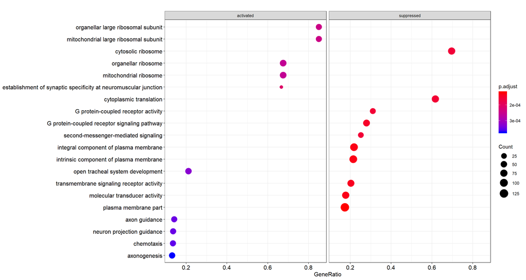

```r
dotplot(gse, showCategory=10, split=".sign") + facet_grid(.~.sign)
```

## Encrichment plot map:

Enrichment map organizes enriched terms into a network with edges connecting overlapping gene sets. In this way, mutually overlapping gene sets are tend to cluster together, making it easy to identify functional modules.

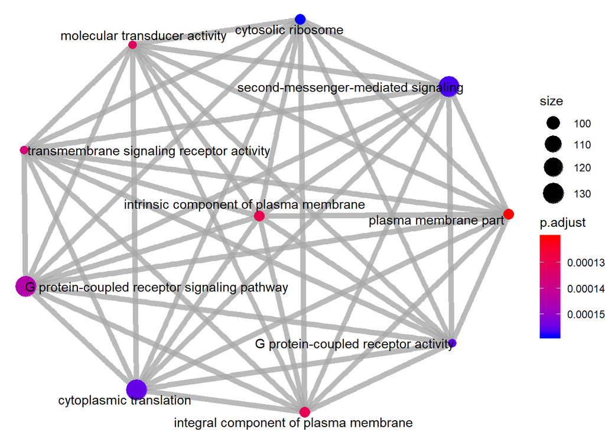

```r
emapplot(gse, showCategory = 10)
```

## Category Netplot

The cnetplot depicts the linkages of genes and biological concepts (e.g. GO terms or KEGG pathways) as a network (helpful to see which genes are involved in enriched pathways and genes that may belong to multiple annotation categories).

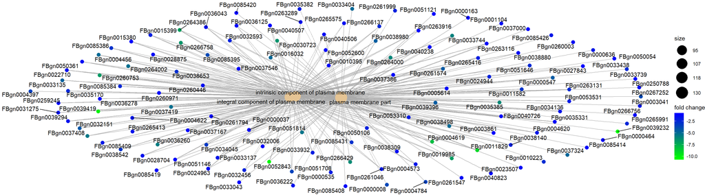

```r
# categorySize can be either 'pvalue' or 'geneNum'
cnetplot(gse, categorySize="pvalue", foldChange=gene_list, showCategory = 3)
```

## Ridgeplot

Helpful to interpret up/down-regulated pathways.

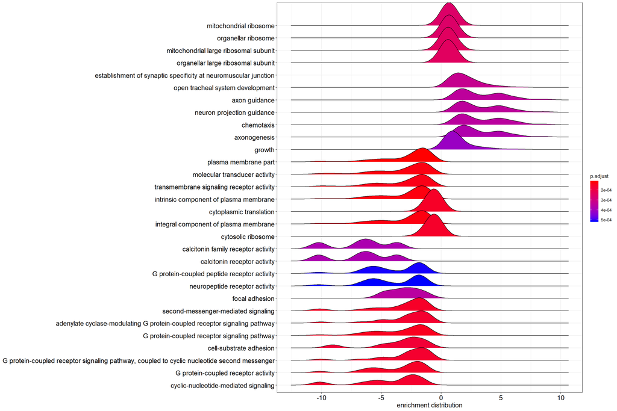

```r
ridgeplot(gse) + labs(x = "enrichment distribution")
```

## GSEA Plot

Traditional method for visualizing GSEA result.

Params:  
**Gene Set** Integer. Corresponds to gene set in the gse object. The first gene set is 1, second gene set is 2, etc.

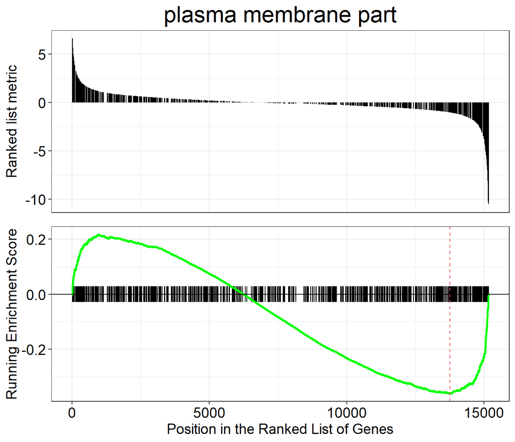

```r
# Use the `Gene Set` param for the index in the title, and as the value for geneSetId
gseaplot(gse, by = "all", title = gse$Description[1], geneSetID = 1)
```

## PubMed trend of enriched terms

Plots the number/proportion of publications trend based on the query result from PubMed Central.

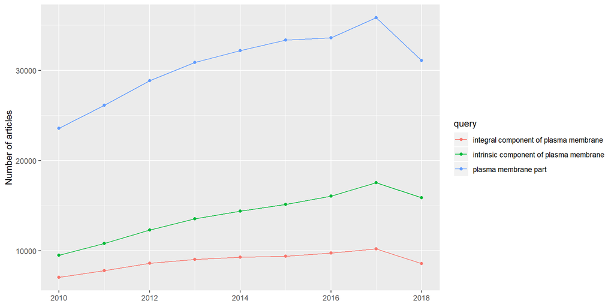

```r
terms <- gse$Description[1:3]
pmcplot(terms, 2010:2018, proportion=FALSE)
```

# KEGG Gene Set Enrichment Analysis

For KEGG pathway enrichment using the `gseKEGG()` function, we need to convert id types. We can use the `bitr` function for this (included in clusterProfiler). It is normal for this call to produce some messages / warnings.

In the `bitr` function, the param `fromType` should be the same as `keyType` from the `gseGO` function above (the annotation source). This param is used again in the next two steps: creating `dedup_ids` and `df2`.

`toType` in the `bitr` function has to be one of the available options from `keyTypes(org.Dm.eg.db)` and must map to one of ‘kegg’, ‘ncbi-geneid’, ‘ncib-proteinid’ or ‘uniprot’ because `gseKEGG()` only accepts one of these 4 options as it’s `keytype` parameter. In the case of org.Dm.eg.db, none of those 4 types are available, but ‘ENTREZID’ are the same as ncbi-geneid for org.Dm.eg.db so we use this for `toType`.

As our intial input, we use `original_gene_list` which we created above.

## Prepare Input

```r
# Convert gene IDs for gseKEGG function
# We will lose some genes here because not all IDs will be converted
ids<-bitr(names(original_gene_list), fromType = "ENSEMBL", toType = "ENTREZID", OrgDb=organism)
```

```r
# remove duplicate IDS (here I use "ENSEMBL", but it should be whatever was selected as keyType)
dedup_ids = ids[!duplicated(ids[c("ENSEMBL")]),]

# Create a new dataframe df2 which has only the genes which were successfully mapped using the bitr function above
df2 = df[df$X %in% dedup_ids$ENSEMBL,]

# Create a new column in df2 with the corresponding ENTREZ IDs
df2$Y = dedup_ids$ENTREZID

# Create a vector of the gene unuiverse
kegg_gene_list <- df2$log2FoldChange

# Name vector with ENTREZ ids
names(kegg_gene_list) <- df2$Y

# omit any NA values
kegg_gene_list<-na.omit(kegg_gene_list)

# sort the list in decreasing order (required for clusterProfiler)
kegg_gene_list = sort(kegg_gene_list, decreasing = TRUE)
```

## Create gseKEGG object

**organism** KEGG Organism Code: The full list is here: https://www.genome.jp/kegg/catalog/org_list.html (need the 3 letter code). I define this as `kegg_organism` first, because it is used again below when making the pathview plots.  
**nPerm** permutation numbers, the higher the number of permutations you set, the more accurate your results is, but it will also cost longer time for running permutation.  
**minGSSize** minimal size of each geneSet for analyzing.  
**maxGSSize** maximal size of genes annotated for testing.  
**pvalueCutoff** pvalue Cutoff.  
**pAdjustMethod** one of “holm”, “hochberg”, “hommel”, “bonferroni”, “BH”, “BY”, “fdr”, “none”.  
**keyType** one of ‘kegg’, ‘ncbi-geneid’, ‘ncib-proteinid’ or ‘uniprot’.

```r
kegg_organism = "dme"
kk2 <- gseKEGG(geneList     = kegg_gene_list,
               organism     = kegg_organism,
               nPerm        = 10000,
               minGSSize    = 3,
               maxGSSize    = 800,
               pvalueCutoff = 0.05,
               pAdjustMethod = "none",
               keyType       = "ncbi-geneid")
```

```
## preparing geneSet collections...
```

```
## GSEA analysis...
```

```
## leading edge analysis...
```

```
## done...
```

```r
head(kk2, 10)
```

|  | ID | Description | setSize | enrichmentScore | NES | pvalue | p.adjust | qvalues | rank | leading_edge | core_enrichment |
| --- | --- | --- | --- | --- | --- | --- | --- | --- | --- | --- | --- |
| dme00053 | dme00053 | Ascorbate and aldarate metabolism | 31 | -0.6716021 | -1.853745 | 0.001177658 | 0.001177658 | 0.1173902 | 51 | tags=16%, list=0%, signal=16% | 53507/35138/34256/35139 |
| dme04080 | dme04080 | Neuroactive ligand-receptor interaction | 50 | -0.5751475 | -1.746620 | 0.001932990 | 0.001932990 | 0.1173902 | 1191 | tags=36%, list=9%, signal=33% | 32703/37892/40955/37191/42530/34878/33248/43669/43551/36601/41639/37004/43484/41726/36368/43838/36475 |
| dme04310 | dme04310 | Wnt signaling pathway | 87 | 0.4423567 | 1.624134 | 0.002835271 | 0.002835271 | 0.1173902 | 2049 | tags=29%, list=16%, signal=24% | 39596/34011/45307/45343/32188/37713/31151/48311/42692/31310/34367/31597/40090/44317/34819/33204/43769/43319/31659/39884/34010/39751/32132/38890/31014 |
| dme00511 | dme00511 | Other glycan degradation | 21 | -0.6767705 | -1.720933 | 0.007289136 | 0.007289136 | 0.2263468 | 1380 | tags=57%, list=11%, signal=51% | 37211/34203/34437/37490/32726/41913/38528/34206/35989/41457/42178 |
| dme04130 | dme04130 | SNARE interactions in vesicular transport | 20 | 0.6310228 | 1.720484 | 0.011014764 | 0.011014764 | 0.2736299 | 2529 | tags=50%, list=20%, signal=40% | 36080/40094/42215/36015/248102/38614/40373/38541/40724/39051 |
| dme00330 | dme00330 | Arginine and proline metabolism | 49 | -0.5293307 | -1.601376 | 0.014317889 | 0.014317889 | 0.2964054 | 1993 | tags=24%, list=16%, signal=21% | 326112/40026/46717/43620/34495/41167/40028/50001/43625/326188/34256 |
| dme00380 | dme00380 | Tryptophan metabolism | 20 | -0.6379120 | -1.603860 | 0.023365301 | 0.023365301 | 0.3629602 | 1258 | tags=25%, list=10%, signal=23% | 33907/43689/35190/34256 |
| dme00071 | dme00071 | Fatty acid degradation | 32 | -0.5635746 | -1.568074 | 0.026461229 | 0.026461229 | 0.3629602 | 2598 | tags=41%, list=21%, signal=32% | 34276/34315/34313/41311/37445/41480/40059/42364/31695/37217/35213/34256 |
| dme00830 | dme00830 | Retinol metabolism | 31 | -0.5586698 | -1.542032 | 0.031123822 | 0.031123822 | 0.3629602 | 1762 | tags=23%, list=14%, signal=19% | 41311/38598/53584/53507/35138/35139 |
| dme00040 | dme00040 | Pentose and glucuronate interconversions | 45 | -0.5039618 | -1.500674 | 0.037043054 | 0.037043054 | 0.3629602 | 117 | tags=20%, list=1%, signal=20% | 53513/39305/53584/53507/38463/35586/35138/35139 |

## Dotplot

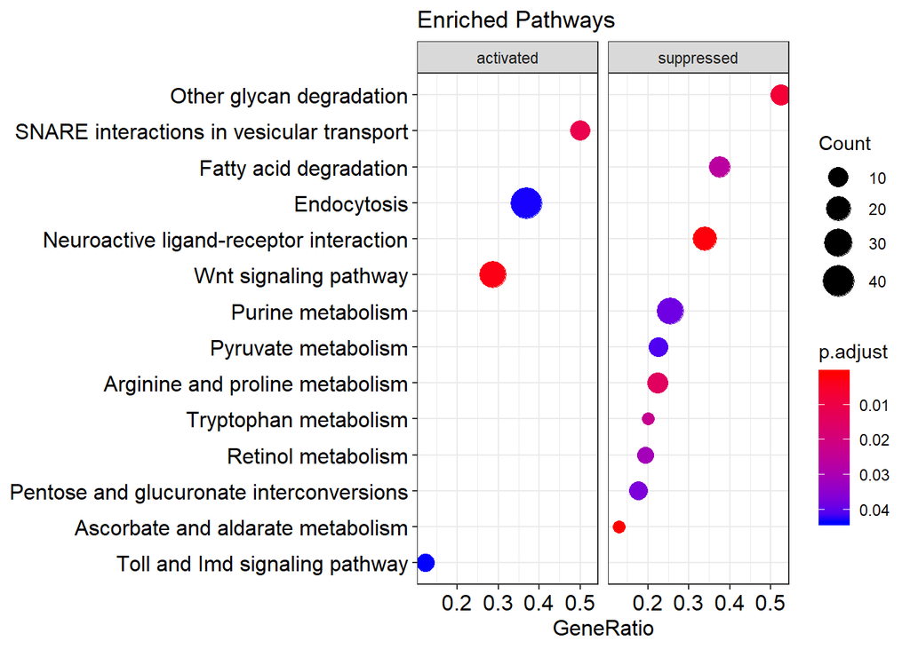

```r
dotplot(kk2, showCategory = 10, title = "Enriched Pathways" , split=".sign") + facet_grid(.~.sign)
```

## Encrichment plot map:

Enrichment map organizes enriched terms into a network with edges connecting overlapping gene sets. In this way, mutually overlapping gene sets are tend to cluster together, making it easy to identify functional modules.

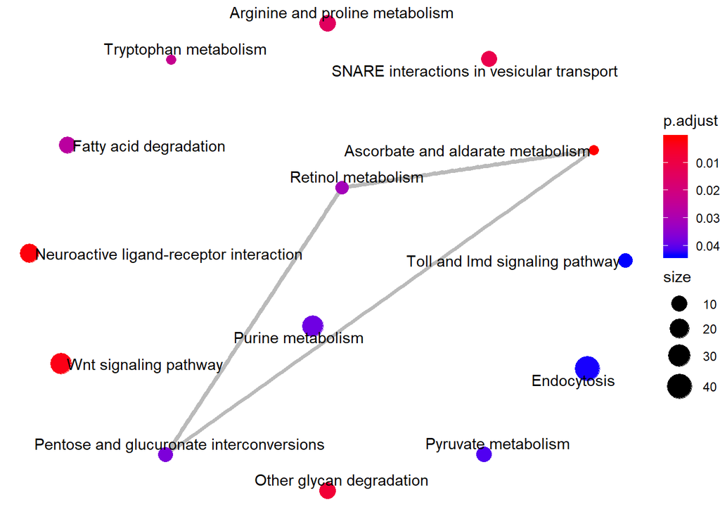

```r
 emapplot(kk2)
```

## Category Netplot:

The cnetplot depicts the linkages of genes and biological concepts (e.g. GO terms or KEGG pathways) as a network (helpful to see which genes are involved in enriched pathways and genes that may belong to multiple annotation categories).

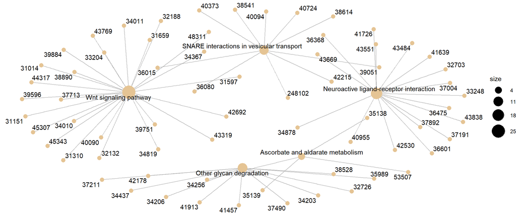

```r
# categorySize can be either 'pvalue' or 'geneNum'
cnetplot(kk2, categorySize="pvalue", foldChange=gene_list)
```

## Ridgeplot

Helpful to interpret up/down-regulated pathways.

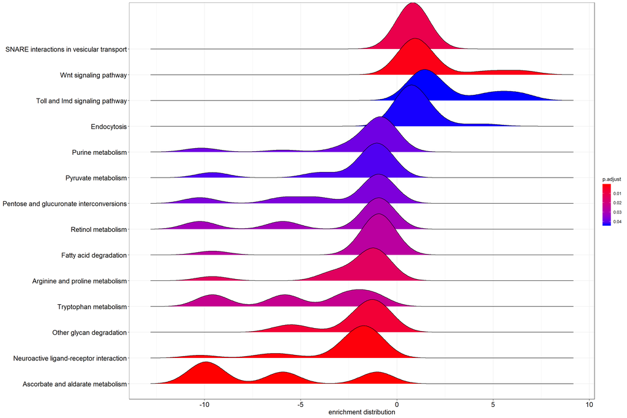

```r
ridgeplot(kk2) + labs(x = "enrichment distribution")
```

# GSEA Plot

Traditional method for visualizing GSEA result.

Params:  
**Gene Set** Integer. Corresponds to gene set in the gse object. The first gene set is 1, second gene set is 2, etc. Default: 1

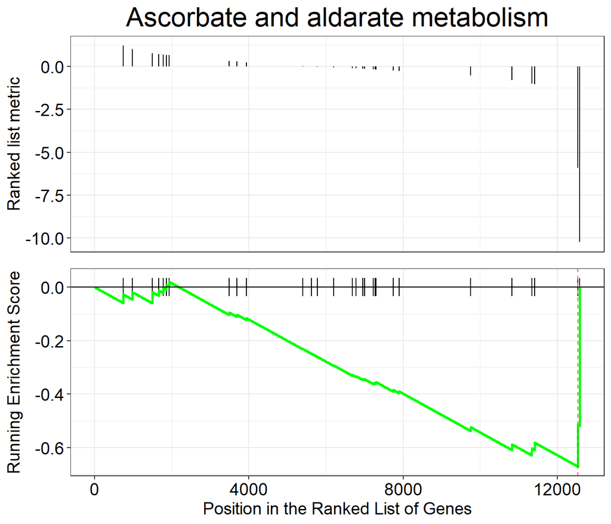

```r
# Use the `Gene Set` param for the index in the title, and as the value for geneSetId
gseaplot(kk2, by = "all", title = kk2$Description[1], geneSetID = 1)
```

# Pathview

This will create a PNG and *different* PDF of the enriched KEGG pathway.

Params:  
**gene.data** This is `kegg_gene_list` created above  
**pathway.id** The user needs to enter this. Enriched pathways + the pathway ID are provided in the gseKEGG output table (above).  
**species** Same as `organism` above in `gseKEGG`, which we defined as `kegg_organism`

```r
library(pathview)

# Produce the native KEGG plot (PNG)
dme <- pathview(gene.data=kegg_gene_list, pathway.id="dme04130", species = kegg_organism)

# Produce a different plot (PDF) (not displayed here)
dme <- pathview(gene.data=kegg_gene_list, pathway.id="dme04130", species = kegg_organism, kegg.native = F)
```

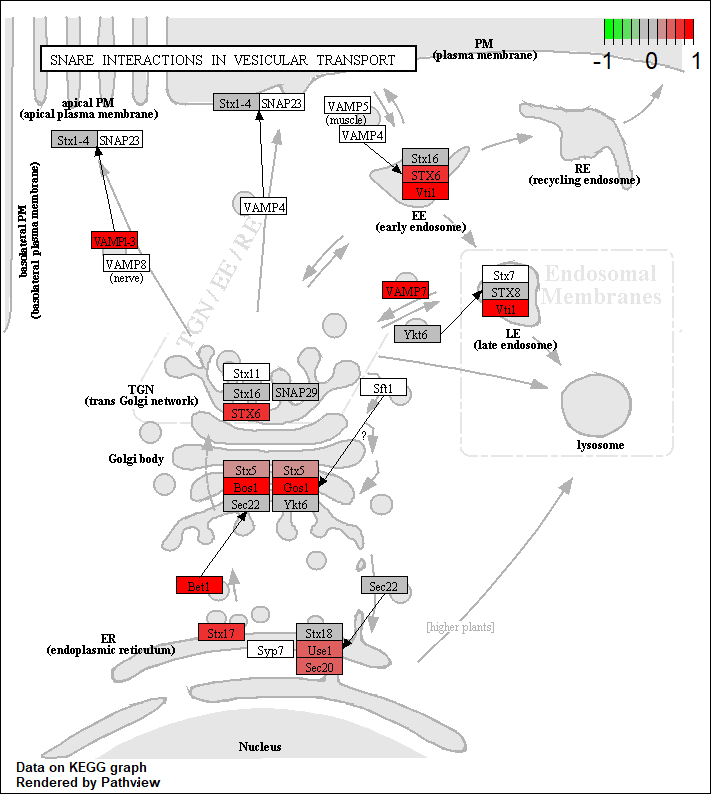

KEGG Native Enriched Pathway Plot

```r
knitr::include_graphics("dme04130.pathview.png")
```